# Fitting Extreme Value Distributions & Copula Estimation

```
##
## Summary for SPex_weibull_shift :
## Fitting of the distribution ' weibull ' by maximum likelihood
## Parameters :
##        estimate Std. Error
## shape  22.10624  1.4101774
## scale 100.89178  0.4155944
## Loglikelihood:  -408.7176   AIC:  821.4353   BIC:  827.2458
## Correlation matrix:
##          shape    scale
## shape 1.000000 0.326729
## scale 0.326729 1.000000
##
##
## Plot for SPex_weibull_shift :
```

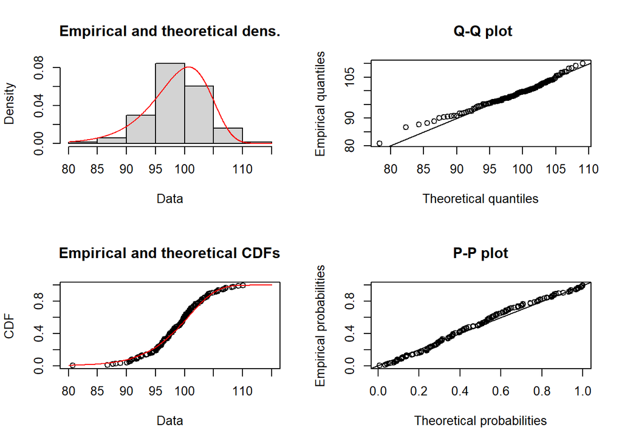

```
##
## Summary for SPex_lnorm_shift :
## Fitting of the distribution ' lnorm ' by maximum likelihood
## Parameters :
##           estimate  Std. Error
## meanlog 4.58991961 0.004352145
## sdlog   0.05056735 0.003072017
## Loglikelihood:  -408.2952   AIC:  820.5904   BIC:  826.401
## Correlation matrix:
##         meanlog sdlog
## meanlog       1     0
## sdlog         0     1
##
##
## Plot for SPex_lnorm_shift :
```

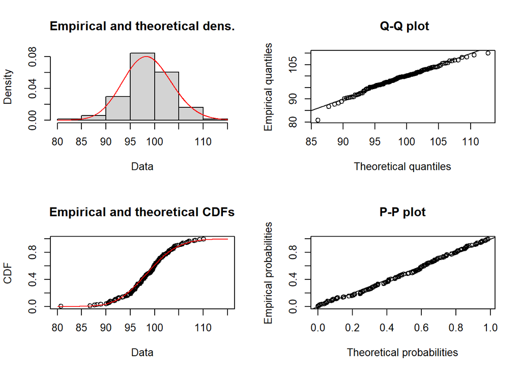

```
##
## Summary for SPex_gamma_shift :
## Fitting of the distribution ' gamma ' by maximum likelihood
## Parameters :
##         estimate Std. Error
## shape 395.015127 48.1191636
## rate    4.005797  0.4882783
## Loglikelihood:  -407.6808   AIC:  819.3616   BIC:  825.1722
## Correlation matrix:
##           shape      rate
## shape 1.0000000 0.9993687
## rate  0.9993687 1.0000000
##
##
## Plot for SPex_gamma_shift :
```

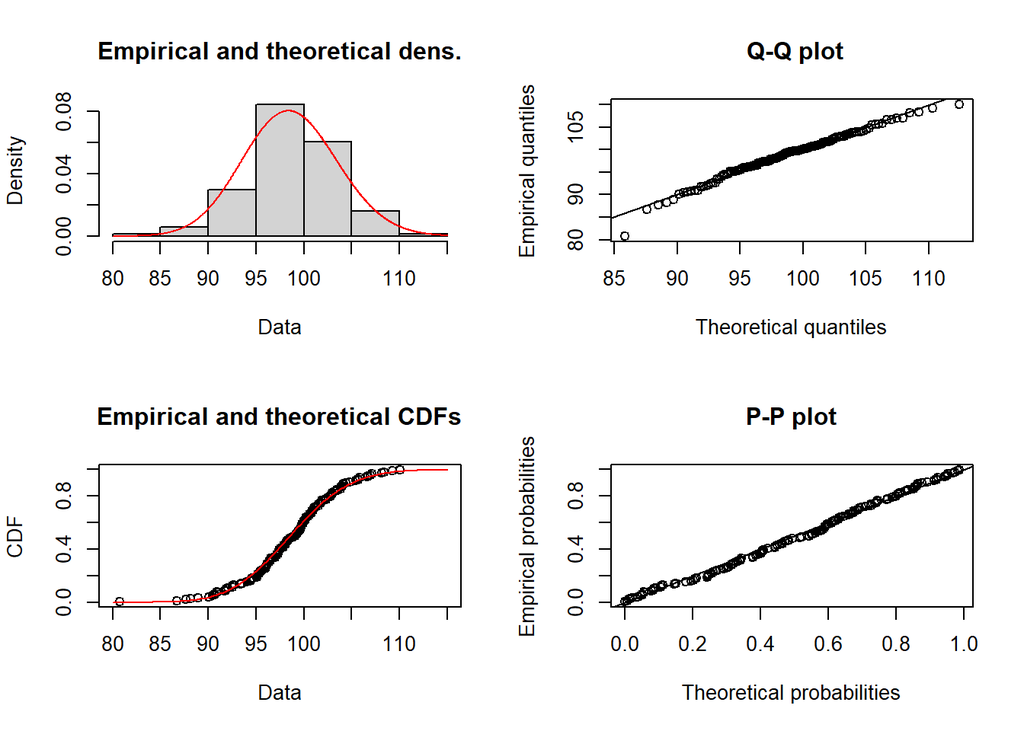

```
##
## Summary for SPex_weibull_pos :
## Fitting of the distribution ' weibull ' by maximum likelihood
## Parameters :
##       estimate Std. Error
## shape 1.166039  0.1304217
## scale 3.394364  0.4194595
## Loglikelihood:  -114.247   AIC:  232.4941   BIC:  236.4346
## Correlation matrix:
##           shape     scale
## shape 1.0000000 0.3026815
## scale 0.3026815 1.0000000
##
##
## Plot for SPex_weibull_pos :
```

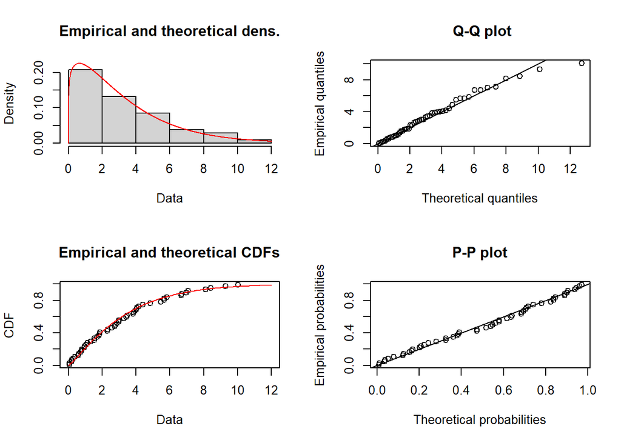

```
##
## Summary for SPex_lnorm_pos :
## Fitting of the distribution ' lnorm ' by maximum likelihood
## Parameters :
##         estimate Std. Error
## meanlog 0.698775  0.1626861
## sdlog   1.184373  0.1150361
## Loglikelihood:  -121.2071   AIC:  246.4143   BIC:  250.3548
## Correlation matrix:
##         meanlog sdlog
## meanlog       1     0
## sdlog         0     1
##
##
## Plot for SPex_lnorm_pos :
```

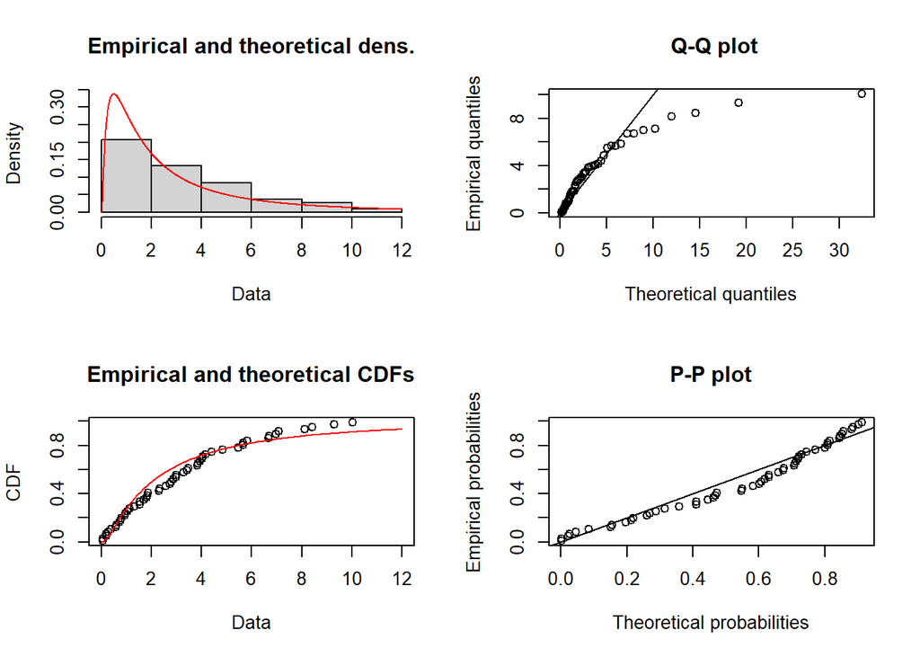

```
##
## Summary for SPex_gamma_pos :
## Fitting of the distribution ' gamma ' by maximum likelihood
## Parameters :
##       estimate Std. Error
## shape 1.194959 0.20754397
## rate  0.370044 0.07932626
## Loglikelihood:  -114.6253   AIC:  233.2506   BIC:  237.1911
## Correlation matrix:
##           shape      rate
## shape 1.0000000 0.8101927
## rate  0.8101927 1.0000000
##
##
## Plot for SPex_gamma_pos :
```

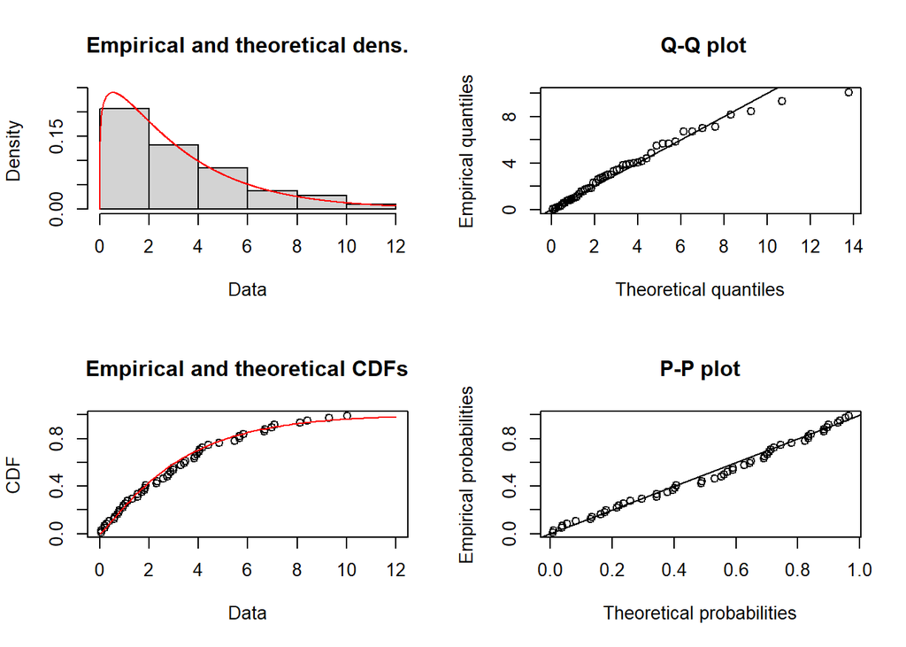

```
##
## Summary for SPex_weibull_abs :
## Fitting of the distribution ' weibull ' by maximum likelihood
## Parameters :
##       estimate Std. Error
## shape 1.142878 0.07861553
## scale 4.106086 0.32464875
## Loglikelihood:  -317.7973   AIC:  639.5945   BIC:  645.4051
## Correlation matrix:
##           shape     scale
## shape 1.0000000 0.3053597
## scale 0.3053597 1.0000000
##
##
## Plot for SPex_weibull_abs :
```

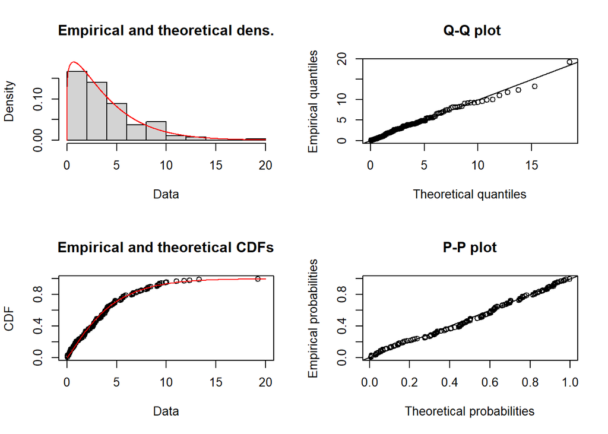

```
##
## Summary for SPex_lnorm_abs :
## Fitting of the distribution ' lnorm ' by maximum likelihood
## Parameters :
##          estimate Std. Error
## meanlog 0.8883773 0.10179812
## sdlog   1.1827872 0.07198191
## Loglikelihood:  -334.1506   AIC:  672.3012   BIC:  678.1117
## Correlation matrix:
##         meanlog sdlog
## meanlog       1     0
## sdlog         0     1
##
##
## Plot for SPex_lnorm_abs :
```

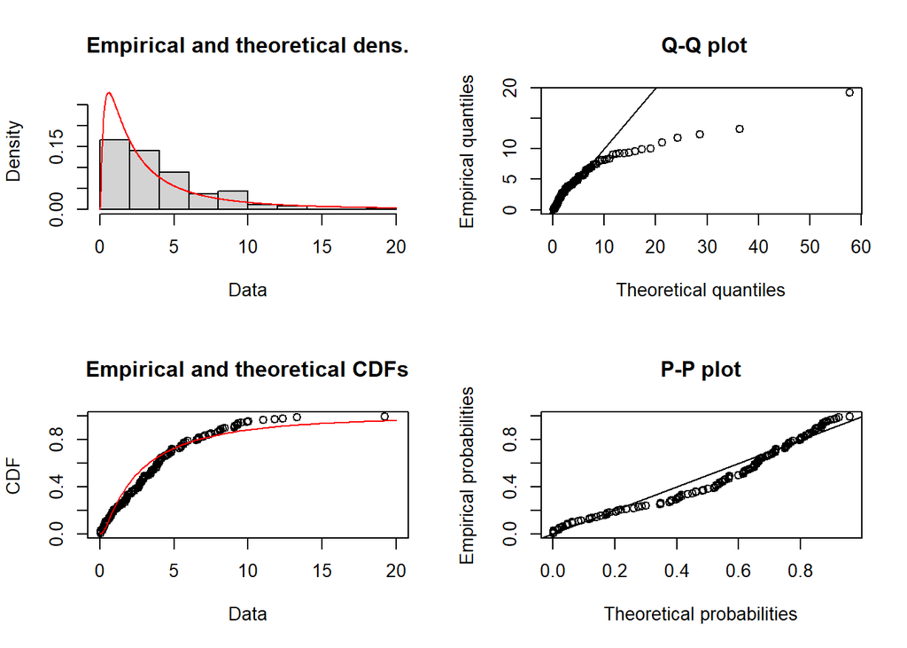

```
##
## Summary for SPex_gamma_abs :
## Fitting of the distribution ' gamma ' by maximum likelihood
## Parameters :
##        estimate Std. Error
## shape 1.1831235 0.12864573
## rate  0.3015389 0.04054931
## Loglikelihood:  -318.4225   AIC:  640.845   BIC:  646.6555
## Correlation matrix:
##           shape      rate
## shape 1.0000000 0.8085694
## rate  0.8085694 1.0000000
##
##
## Plot for SPex_gamma_abs :
```

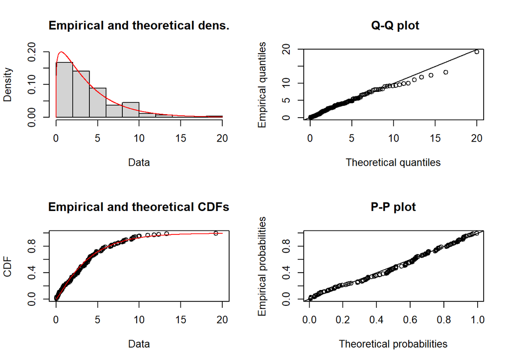

```r
distributions = c("weibull", "lnorm", "gamma")
approaches = list(returns$SPex+100, returns$SPex[returns$SPex>0], abs(returns$SPex))
fit_results <- list()

for (approach in seq_along(approaches)) {
  data <- approaches[[approach]]
  approach_name <- switch(approach, "shift", "pos", "abs")

  for (dist in distributions) {

    fit <- fitdist(data,
                 distr = dist,
                 method = "mle")

  # Store fit results
  fit_results[[paste("SPex_", dist, "_", approach_name, sep = "")]] <- fit

  # Print summary
  cat("\nSummary for", paste("SPex_", dist, "_", approach_name, sep = ""), ":\n")
    print(summary(fit))

    # Plot
    cat("\nPlot for", paste("SPex_", dist, "_", approach_name, sep = ""), ":\n")
    plot(fit)
    }
}
```

However, examining all approach-distribution combinations, the comparison between the theoretical and empirical CDFs, PDFs as well as QQ- and PP-plots for the gamma distribution fitted to the shifted time series values could be suggested as the best fit. The density function fits well the empirical histogram and almoast all data points lie on the theoratical CDF and QQ-/PP- probabilities.

## 1.3 Fitting GEV Distribution

Generalized extreme value distributions are usually fitted to extreme value distributions extracted by the Block Maxima method. To fit such an GEV to our time series, we might want to follow this Block Maxima method. Given the small sample size of 135 observations, we should aim at keeping as many data points as possible. Thus, we will extract the quarterly block maxima:

```r
# Apply blockmax function to extract (e.g. quarterly) maximum values
blockmax<- blockmaxxer(returns, # data frame
              which = "Fordex", # define variable of interest
              blocks = NULL, # self defined blocks
              blen = 3, # block length
              span = 45) #number of blocks
# To get quarterly data, we choose blen = 12/4 = 3 and thus span = 135/3 = 45
```

Subsequently, we fit an GEV distribution to our block maxima data.

```r
gev <-gevFit(blockmax$Fordex,
       block = 1,
       type = c("mle"),
       title = NULL,
       description = NULL)
summary(gev)
```

```
##
## Title:
##  GEV Parameter Estimation
##
## Call:
##  gevFit(x = blockmax$Fordex, block = 1, type = c("mle"), title = NULL,
##     description = NULL)
##
## Estimation Type:
##   gev mle
##
## Estimated Parameters:
##          xi          mu        beta
##  0.05481751  3.34826814 10.54371462
##
## Standard Deviations:
##          xi         mu       beta
## 0.08512318 1.72395888 1.24279856
##
## Log-Likelihood Value:
##   178.0438
##
## Type of Convergence:
##   0
##
## Description
##   Sun Jun 30 22:21:02 2024
```

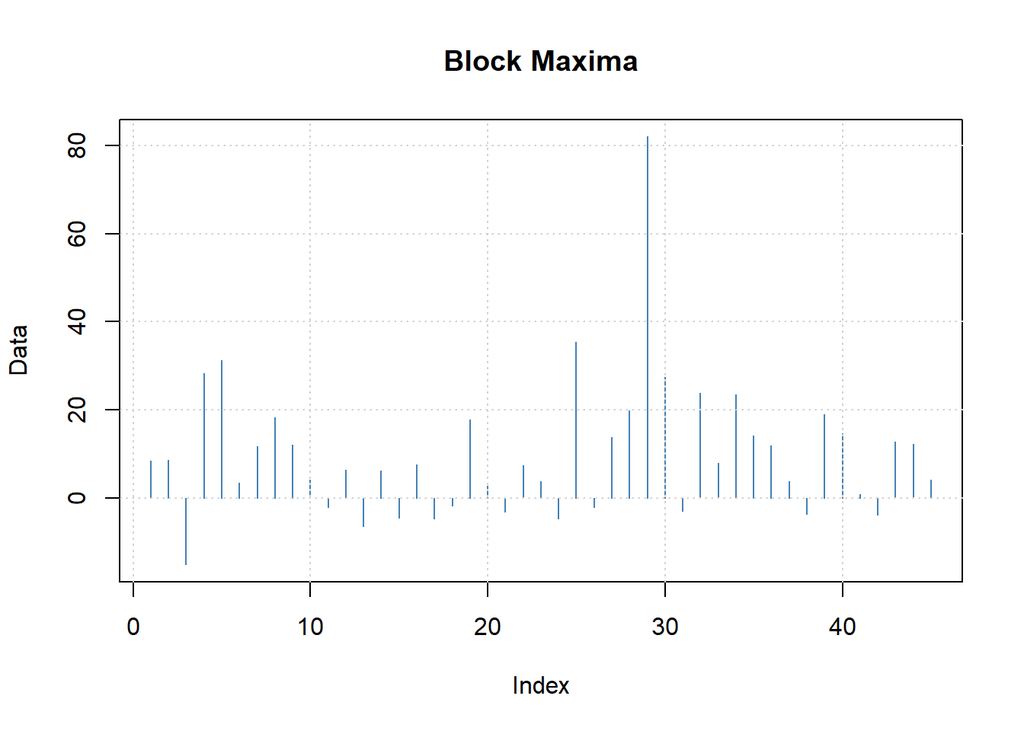

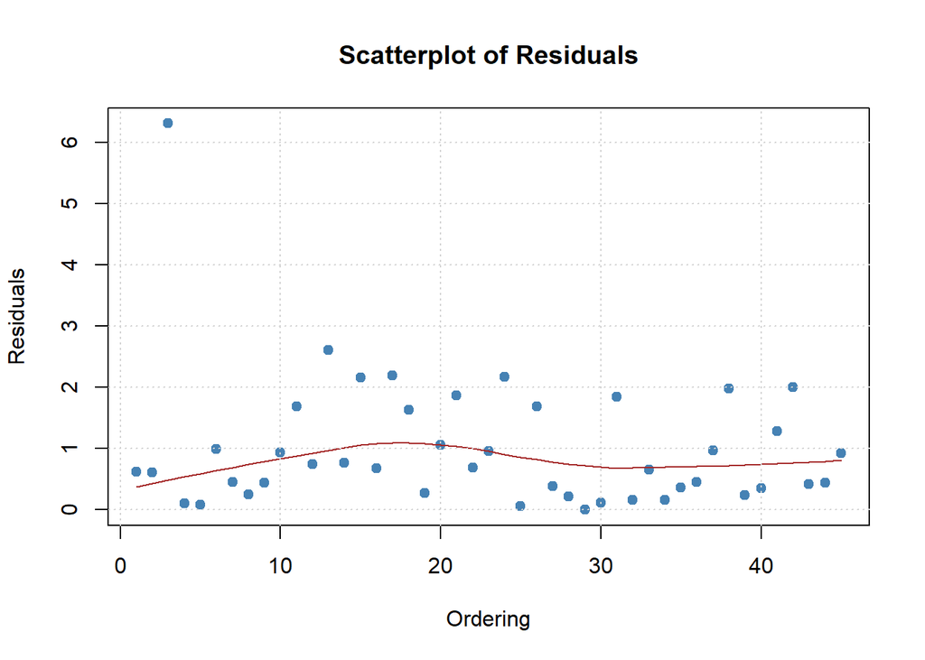

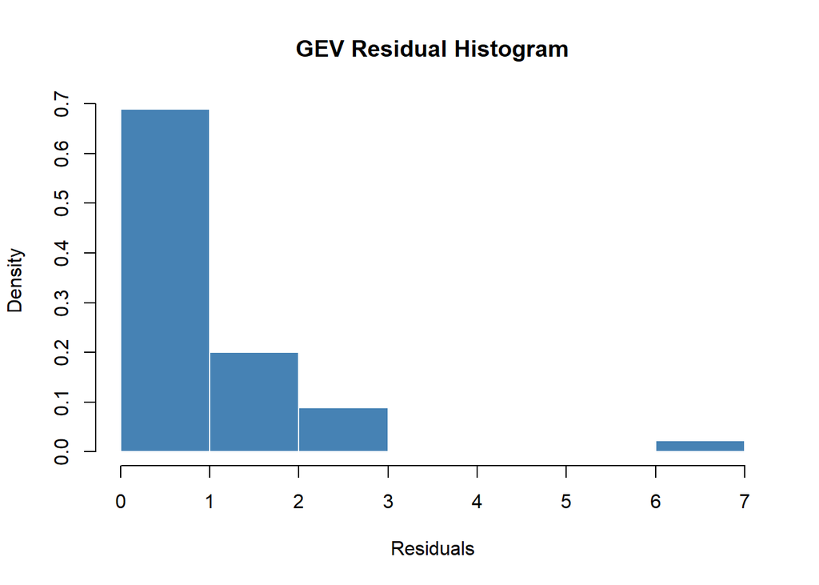

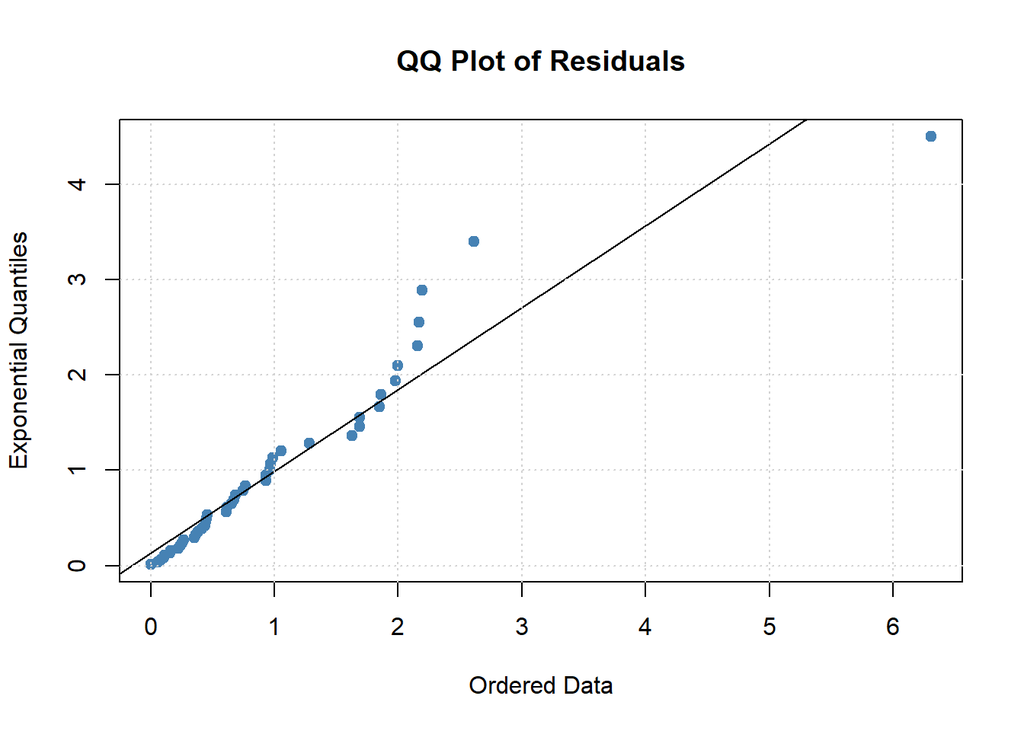

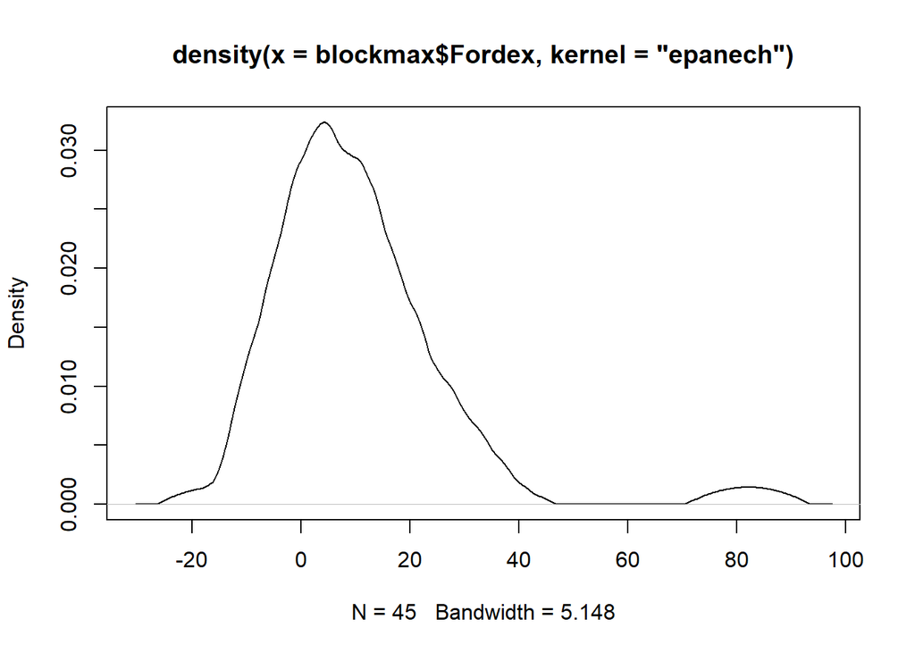

```r
plot(density(blockmax$Fordex, kernel = "epanech"))
```

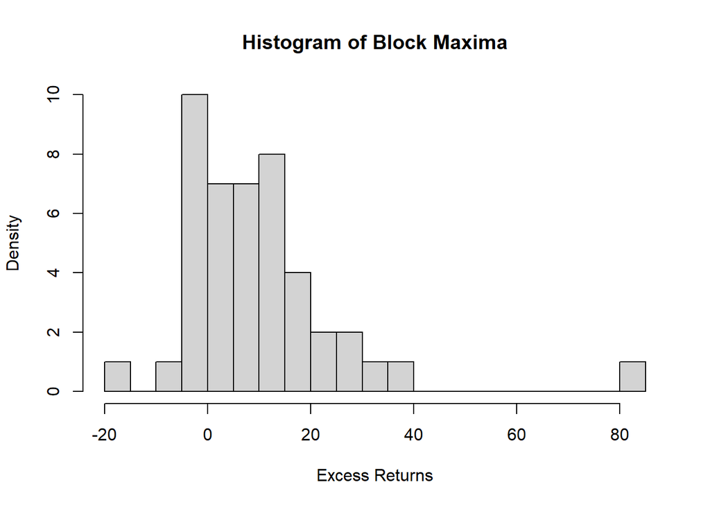

```r
hist(blockmax$Fordex, breaks = 30, main = "Histogram of Block Maxima", xlab = "Excess Returns", ylab = "Density")
```

xi is the shape parameter, mu the location parameter, beta is the scale parameter.

Alternatively, we could fit a GEV distribution to the complete Fordex time series and examine the results. From the preliminary analysis, we know that the Fordex time series is rather normally distributed (density plot). Thus, we expect that a GEV distribution will not describe the data well.

```r
gev2 <-gevFit(returns$Fordex,
       block = 1,
       type = c("mle"),
       title = NULL,
       description = NULL)
summary(gev2)
```

```
##
## Title:
##  GEV Parameter Estimation
##
## Call:
##  gevFit(x = returns$Fordex, block = 1, type = c("mle"), title = NULL,
##     description = NULL)
##
## Estimation Type:
##   gev mle
##
## Estimated Parameters:
##         xi         mu       beta
## -0.1832327 -7.8240471 18.6644189
##
## Standard Deviations:
##          xi         mu       beta
## 0.01523783 1.70160068 0.93998523
##
## Log-Likelihood Value:
##   579.6859
##
## Type of Convergence:
##   0
##
## Description
##   Sun Jun 30 22:21:03 2024
```

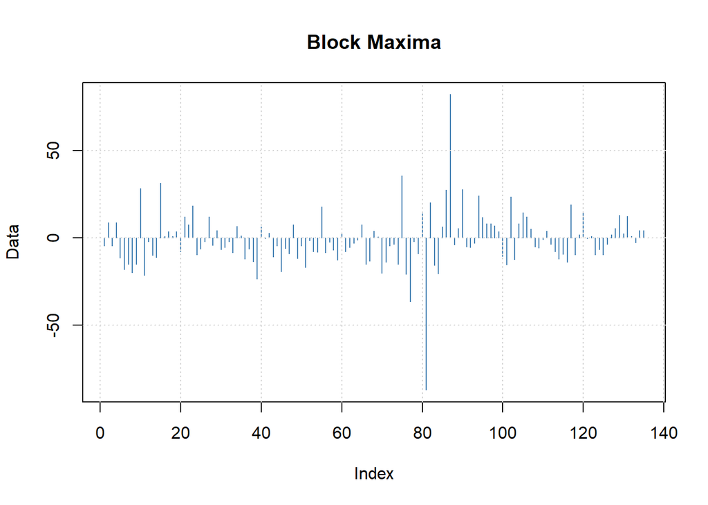

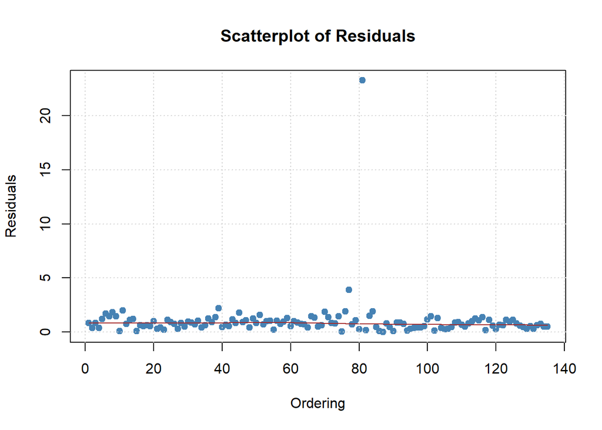

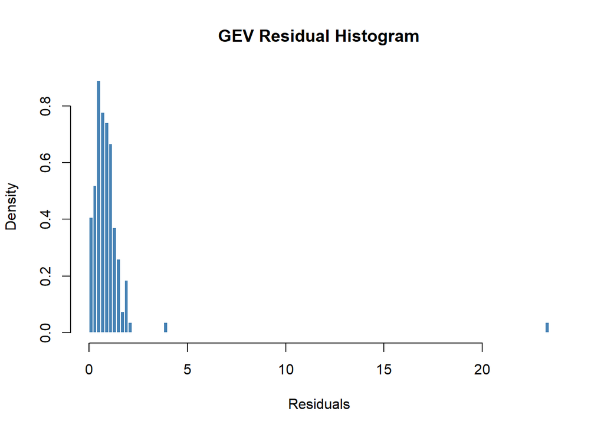

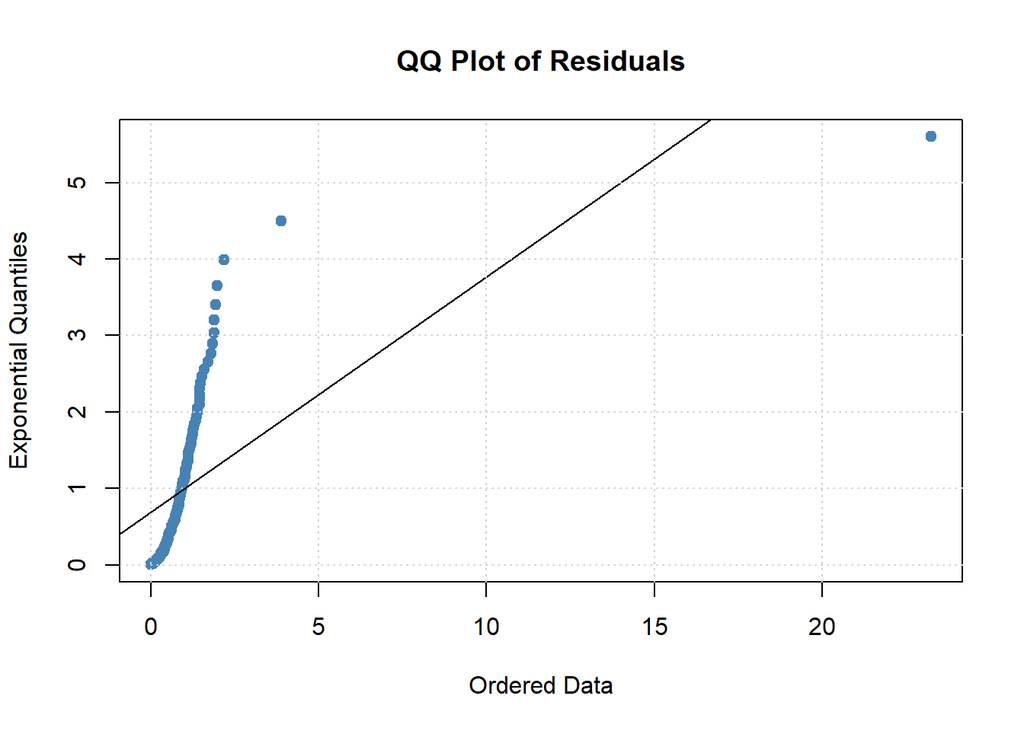

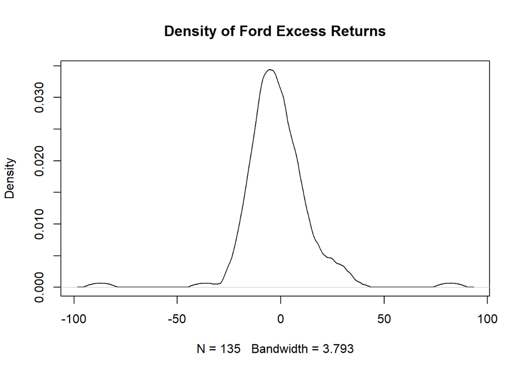

```r
plot(density(returns$Fordex, kernel = "epanech"), main = "Density of Ford Excess Returns")
```

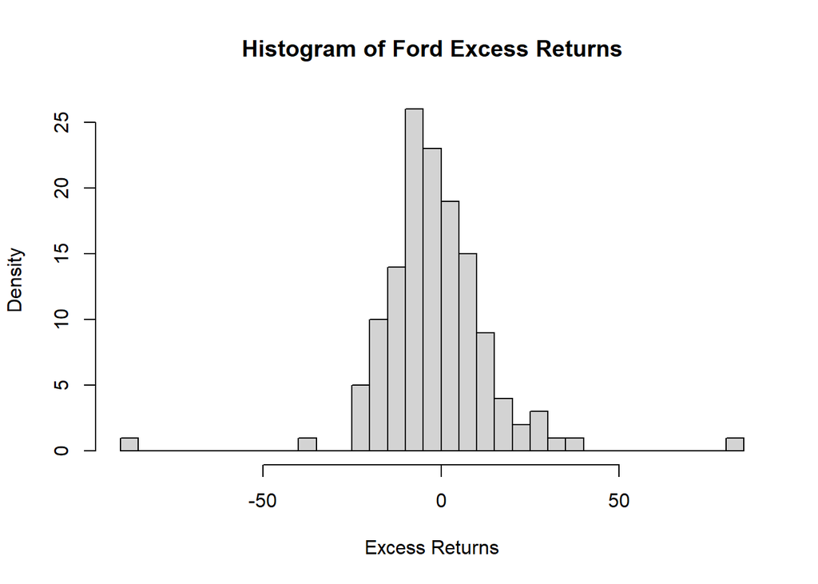

```r
hist(returns$Fordex, breaks = 30, main = "Histogram of Ford Excess Returns", xlab = "Excess Returns", ylab = "Density")
```

## 1.4 Eliptical Copula

Data Transformation

```r
#Create data frame with both time series
returns_vec <- cbind(returns$Fordex, returns$SPex)

# Transform the data to uniform values between [0,1]
margins <- pobs(as.matrix(returns_vec))
```

```r
# Define Guassian and t Copula
cop_norm <- normalCopula(dim = 2) # dim = 2, since we have two margins
cop_t <- tCopula(dim=2)

# Fitting the Copulas to our margins using MLE
fitml_norm <- fitCopula(cop_norm, margins, method = "ml")
fitml_t <- fitCopula(cop_t, margins, method = "ml")

# Compare the models based on log-likelihood
logli_comp <- c(logLik(fitml_norm), logLik(fitml_t))
names(logli_comp) <- c("norm", "t")

# Get the AIC values
AIC <- AIC(fitml_norm, fitml_t)

# Get quality results
print(logli_comp)
```

```
##     norm        t
## 28.49604 38.40919
```

```r
print(AIC)
```

```
##            df       AIC
## fitml_norm  1 -54.99207
## fitml_t     2 -72.81838
```

```r
# Obtain Parameters for the normal copula (best AIC & Log-Liklihood values)
summary(fitml_norm)
```

```
## Call: fitCopula(cop_norm, data = margins, ... = pairlist(method = "ml"))
## Fit based on "maximum likelihood" and 135 2-dimensional observations.
## Normal copula, dim. d = 2
##       Estimate Std. Error
## rho.1   0.6046      0.048
## The maximized loglikelihood is 28.5
## Optimization converged
## Number of loglikelihood evaluations:
## function gradient
##        6        6
```

```r
summary(fitml_t)
```

```
## Call: fitCopula(cop_t, data = margins, ... = pairlist(method = "ml"))
## Fit based on "maximum likelihood" and 135 2-dimensional observations.
## t-copula, dim. d = 2
##       Estimate Std. Error
## rho.1    0.605      0.068
## df       2.090      0.634
## The maximized loglikelihood is 38.41
## Optimization converged
## Number of loglikelihood evaluations:
## function gradient
##       15       15
```

The t-copula provides the better fit with an AIC of -72.81838 (compared to the normal copular with an AIC of -54.99207) and a log-liklihood of 38.41 (compared to 28.5). Thus, we will compute the Kendall’s tau based on the tCopula and it’s estimated roh parameter of 0.605. Moreover, the degrees of freedom of 2.090, indicates that the t copula does not behave like a normal copula but the has heavier tails.

Estimate Kendall’s Tau

```r
# Check Kendall's tau value for the best fitted copula, here the t-copula
tau(tCopula(param = 0.605))
```

```
## [1] 0.4136538
```

We obtain a Kendall’s tau value of 0.4136538 > 0, indication comonotonicity of the two time series. Put differently, the excess returns of the Ford stock and the S&P500 market index show positive dependence, i.e. if the S&P500 market index is in a bull market, the Ford excess returns will be promissing as well.

## 1.5 Archimedian Copulas

```r
# Define Clayton and Gumbel Copulas
cop_clay <- claytonCopula(dim = 2) # dim = 2, since we have two margins
cop_gumb <- gumbelCopula(dim=2)

# Fitting the Copulas to our margins using MLE
fitml_clay <- fitCopula(cop_clay, margins, method = "ml")
fitml_gumb <- fitCopula(cop_gumb, margins, method = "ml")

# Compare the models based on log-likelihood
logli_comp <- c(logLik(fitml_clay), logLik(fitml_gumb))
names(logli_comp) <- c("clayton", "gumbel")

# Get the AIC values
AIC <- AIC(fitml_clay, fitml_gumb)

# Get quality results
print(logli_comp)
```

```
##  clayton   gumbel
## 23.44808 32.84128
```

```r
print(AIC)
```

```
##            df       AIC
## fitml_clay  1 -44.89616
## fitml_gumb  1 -63.68256
```

```r
# Obtain Parameters for the normal copula (best AIC & Log-Liklihood values)
summary(fitml_clay)
```

```
## Call: fitCopula(cop_clay, data = margins, ... = pairlist(method = "ml"))
## Fit based on "maximum likelihood" and 135 2-dimensional observations.
## Clayton copula, dim. d = 2
##       Estimate Std. Error
## alpha    1.395        0.2
## The maximized loglikelihood is 23.45
## Optimization converged
## Number of loglikelihood evaluations:
## function gradient
##        3        3
```

```r
summary(fitml_gumb)
```

```
## Call: fitCopula(cop_gumb, data = margins, ... = pairlist(method = "ml"))
## Fit based on "maximum likelihood" and 135 2-dimensional observations.
## Gumbel copula, dim. d = 2
##       Estimate Std. Error
## alpha    1.751      0.125
## The maximized loglikelihood is 32.84
## Optimization converged
## Number of loglikelihood evaluations:
## function gradient
##        6        6
```

For our two the (archimedian) Clayton and Gumbel copulas, we obtain a log-likelihood of 23.44808 and 32.84128, respectively. The corresponding AIC values of -44.89616 and -63.68256 confirm these results and identify the Gumbel copula with an alpha value of 1.751 as the better fit.

Estimate Kendall’s Tau

```r
# Check Kendall's tau value for the best fitted copula, here the t-copula
tau(gumbelCopula(param = 1.751))
```

```
## [1] 0.4288978
```

With a Kendall’s tau estimate of 0.4288978 > 0, the archimedian Gumbel copula yields a similar result as the elliptical t Copula. I.e. the S&P500 and Ford excess returns show a positive dependence relation. In other words, the Kendall’s tau greater than zero indicates comonotonicity of the two time series.